# Phylogenetic Comparative Methods

Dean Adams (dcadams@iastate.edu)

2017-04-13

### **Motivation**

Today we explore ways in which quantitative analyses may be performed in light of phylogenetic relationshps. When species trait values are used as data, we encounter a non-independence issue: species are not independent because they exhibit a shared evolutionary history as described by their phylogeny. Thus, the expected covariation between taxa is not iid: N(0,1). Instead, it is N(0,V) where V is an expected covariance matrix described by the phylogeny and the evolutionary model under consideration.

Numerous analytical methods have been devoped to take phylogeny into account, which collectively are termed *phylogenetic comparative methods* (PCMs). Today we will examine several of the more commonly used PCMs ones.

### Data Setup

Let’s first read in some data, match the data to the phylogeny, and prune both. NOTE: a critical issue in R is that the species names in the data matrix [names(Y) or rownames(Y) depending on input type] match those on the phylogeny [phy$tip.label]:

```r
library(nlme)   # Contains GLS
library(ape)    # Many phylogenetics-related analyses (see Paradis, Analysis of Phylogenetics and Evolution with R)
library(geiger) # Many evolutionary analyses
library(phytools)
library(geomorph) #contains multivariate PCMs
## Read data, phylogeny, and match the two
anolis<-read.table("Data/Lab-12-anolis.SVL.txt", sep=",", header=T)
anolis<-na.exclude(anolis)
anolis[,5:6]<-log10(anolis[,5:6])
    head(anolis)
```

```
##                    Species Island_type    ecomorph geo_ecomorph Female_SVL
## A_ahli         Anolis_ahli LargeIsland TrunkGround            1   1.719331
## A_alayoni   Anolis_alayoni LargeIsland        Twig            2   1.589950
## A_alfaroi   Anolis_alfaroi LargeIsland   GrassBush            2   1.518514
## A_aliniger Anolis_aliniger LargeIsland  TrunkCrown            1   1.755875
## A_allisoni Anolis_allisoni LargeIsland  TrunkCrown            1   1.875061
## A_allogus   Anolis_allogus LargeIsland TrunkGround            1   1.690196
##            Male_SVL
## A_ahli     1.790285
## A_alayoni  1.670246
## A_alfaroi  1.556303
## A_aliniger 1.778151
## A_allisoni 2.000000
## A_allogus  1.797960
```

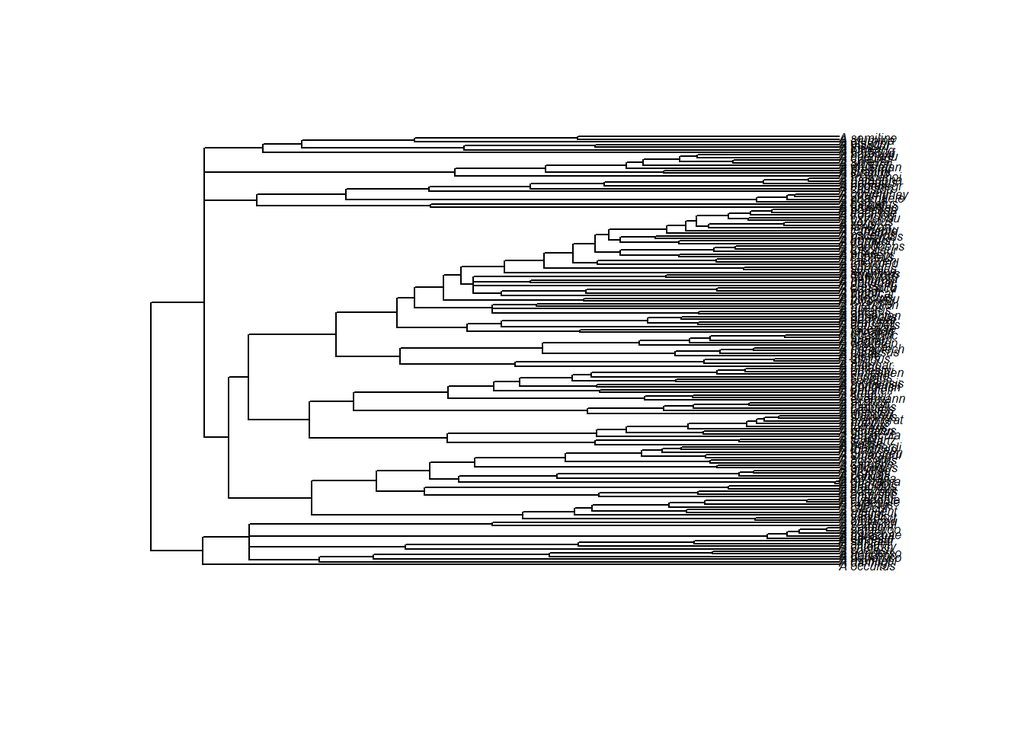

```r
tree<-read.tree("Data/Lab-12-anolis.tree.tre")  #read tree
plot(tree,  cex=0.5)
```

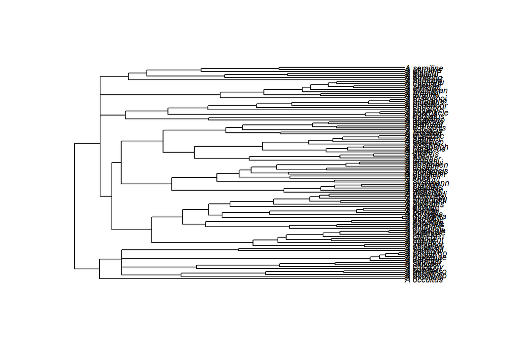

```r
# Prune tree to match taxa
droplist<-setdiff(tree$tip, rownames(anolis))
tree<-drop.tip(tree,droplist)
plot(tree, cex=0.7) # dev.off()  #for fixing plot window if needed
```

```r
#NOTE: the function 'treedata' in geiger prunes both the data matrix and the tree to match

anolis<-anolis[tree$tip,] #re-order data to match tree order (necessary for some functions)
ml<-anolis$Male_SVL; names(ml)<-rownames(anolis)
fml<-anolis$Female_SVL; names(fml)<-rownames(anolis)
ecomorph<-as.factor(anolis$geo_ecomorph); names(ecomorph)<-rownames(anolis)
Y<-cbind(anolis$Male_SVL,anolis$Female_SVL);rownames(Y)<-rownames(anolis)
gdf<-geomorph.data.frame(ml=ml,fml=fml,ecomorph=ecomorph,Y=Y,tree=tree)

  #another dataset (multivariate)
data(plethspecies)
Y.gpa<-gpagen(plethspecies$land, print.progress = FALSE)    #GPA-alignment
land.gps<-c("A","A","A","A","A","B","B","B","B","B","B")
gp.end<-factor(c(0,0,1,0,0,1,1,0,0))  #endangered species vs. rest
names(gp.end)<-plethspecies$phy$tip
```

### **1: Phylogenetic regression/anova**

One may perform models of the form Y~X while accounting for the phylogeny. This is accomplished using generalized least squares (GLS), which is can be implemented as a weighted regression. There are several ways to accomplish this in R, but first let’s examine a non-phylogenetic analysis

```r
anova(lm(anolis$Female_SVL~anolis$Male_SVL))
```

```
## Analysis of Variance Table
##
## Response: anolis$Female_SVL
##                  Df Sum Sq Mean Sq F value    Pr(>F)
## anolis$Male_SVL   1 3.3895  3.3895    1231 < 2.2e-16 ***
## Residuals       104 0.2864  0.0028
## ---
## Signif. codes:  0 '***' 0.001 '**' 0.01 '*' 0.05 '.' 0.1 ' ' 1
```

```r
summary(lm(anolis$Female_SVL~anolis$Male_SVL))
```

```
##
## Call:
## lm(formula = anolis$Female_SVL ~ anolis$Male_SVL)
##
## Residuals:
##       Min        1Q    Median        3Q       Max
## -0.138291 -0.027692  0.000086  0.039378  0.154349
##
## Coefficients:
##                 Estimate Std. Error t value Pr(>|t|)
## (Intercept)      0.03247    0.04922    0.66    0.511
## anolis$Male_SVL  0.94529    0.02694   35.09   <2e-16 ***
## ---
## Signif. codes:  0 '***' 0.001 '**' 0.01 '*' 0.05 '.' 0.1 ' ' 1
##
## Residual standard error: 0.05247 on 104 degrees of freedom
## Multiple R-squared:  0.9221, Adjusted R-squared:  0.9213
## F-statistic:  1231 on 1 and 104 DF,  p-value: < 2.2e-16
```

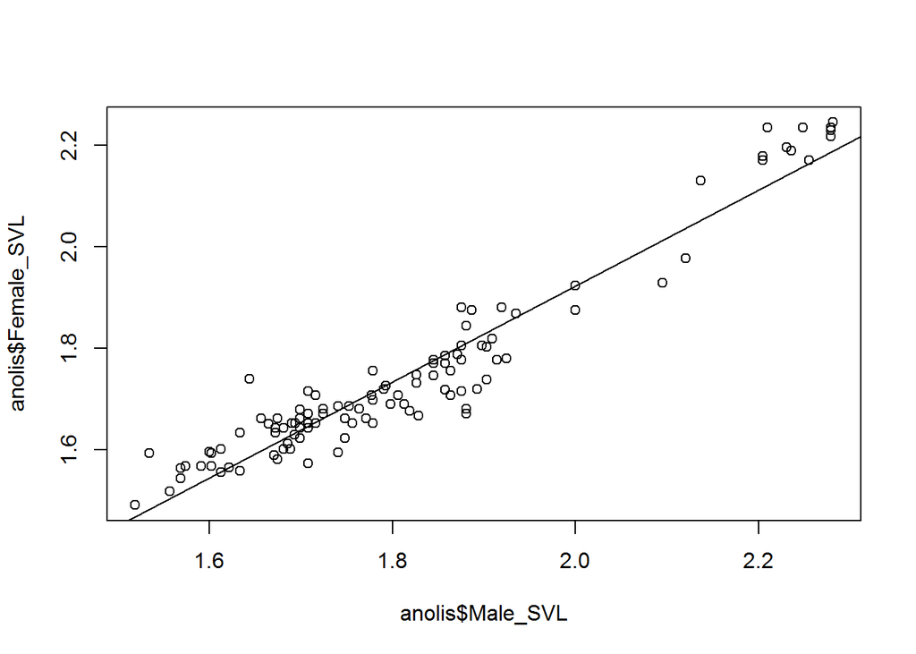

```r
plot(anolis$Female_SVL~anolis$Male_SVL)
abline(lm(anolis$Female_SVL~anolis$Male_SVL))
```

```r
summary(gls(Female_SVL~Male_SVL, data=anolis))
```

```
## Generalized least squares fit by REML
##   Model: Female_SVL ~ Male_SVL
##   Data: anolis
##         AIC       BIC   logLik
##   -305.9342 -298.0011 155.9671
##
## Coefficients:
##                 Value  Std.Error  t-value p-value
## (Intercept) 0.0324733 0.04921827  0.65978  0.5109
## Male_SVL    0.9452906 0.02694245 35.08555  0.0000
##
##  Correlation:
##          (Intr)
## Male_SVL -0.995
##
## Standardized residuals:
##          Min           Q1          Med           Q3          Max
## -2.635456762 -0.527734910  0.001634291  0.750439121  2.941481140
##
## Residual standard error: 0.05247322
## Degrees of freedom: 106 total; 104 residual
```

Now let’s take phylogeny into consideration:

```r
  #using GLS
bm.gls<-gls(Female_SVL~Male_SVL, correlation=corBrownian(phy=tree), data=anolis)
summary(bm.gls)  #Here the correlation structure of the phylogeny is used
```

```
## Generalized least squares fit by REML
##   Model: Female_SVL ~ Male_SVL
##   Data: anolis
##         AIC       BIC   logLik
##   -321.8878 -313.9546 163.9439
##
## Correlation Structure: corBrownian
##  Formula: ~1
##  Parameter estimate(s):
## numeric(0)
##
## Coefficients:
##                 Value  Std.Error   t-value p-value
## (Intercept) 0.2703588 0.07771350  3.478916   7e-04
## Male_SVL    0.8165236 0.04089376 19.966949   0e+00
##
##  Correlation:
##          (Intr)
## Male_SVL -0.957
##
## Standardized residuals:
##        Min         Q1        Med         Q3        Max
## -1.7817369 -0.4748258 -0.1442419  0.2743154  2.1415545
##
## Residual standard error: 0.07520168
## Degrees of freedom: 106 total; 104 residual
```

```r
anova(bm.gls)
```

```
## Denom. DF: 104
##             numDF  F-value p-value
## (Intercept)     1 6106.919  <.0001
## Male_SVL        1  398.679  <.0001
```

```r
  #using D-PGLS: same
pgls.res<-procD.pgls(fml~ml,phy=tree,data=gdf, print.progress = FALSE)
summary(pgls.res)
```

```
##
## Call:
## procD.pgls(f1 = fml ~ ml, phy = tree, data = gdf, print.progress = FALSE)
##
##
##
##
## Type I (Sequential) Sums of Squares and Cross-products
## Randomized Residual Permutation Procedure Used
## 1000 Permutations
##
## *** F values, Z scores, and P values updated for either PGLS or nested effects
##
##            Df        SS        MS     Rsq      F      Z Pr(>F)
## ml          1 0.0244762 0.0244762 0.79311 398.68 29.931  0.001 **
## Residuals 104 0.0063848 0.0000614
## Total     105 0.0308610
## ---
## Signif. codes:  0 '***' 0.001 '**' 0.01 '*' 0.05 '.' 0.1 ' ' 1
```

```r
  #using Independent Contrasts: same
picM<-pic(anolis$Male_SVL, tree)
picF<-pic(anolis$Female_SVL, tree)
cor.test(picM, picF)
```

```
##
##  Pearson's product-moment correlation
##
## data:  picM and picF
## t = 19.549, df = 103, p-value < 2.2e-16
## alternative hypothesis: true correlation is not equal to 0
## 95 percent confidence interval:
##  0.8384903 0.9222981
## sample estimates:
##       cor
## 0.8875224
```

```r
summary(lm(picF~picM - 1)) #Contrasts run through origin: see Garland et al. 1992
```

```
##
## Call:
## lm(formula = picF ~ picM - 1)
##
## Residuals:
##        Min         1Q     Median         3Q        Max
## -0.0225490 -0.0046540 -0.0004036  0.0045798  0.0259094
##
## Coefficients:
##      Estimate Std. Error t value Pr(>|t|)
## picM  0.81652    0.04089   19.97   <2e-16 ***
## ---
## Signif. codes:  0 '***' 0.001 '**' 0.01 '*' 0.05 '.' 0.1 ' ' 1
##
## Residual standard error: 0.007835 on 104 degrees of freedom
## Multiple R-squared:  0.7931, Adjusted R-squared:  0.7911
## F-statistic: 398.7 on 1 and 104 DF,  p-value: < 2.2e-16
```

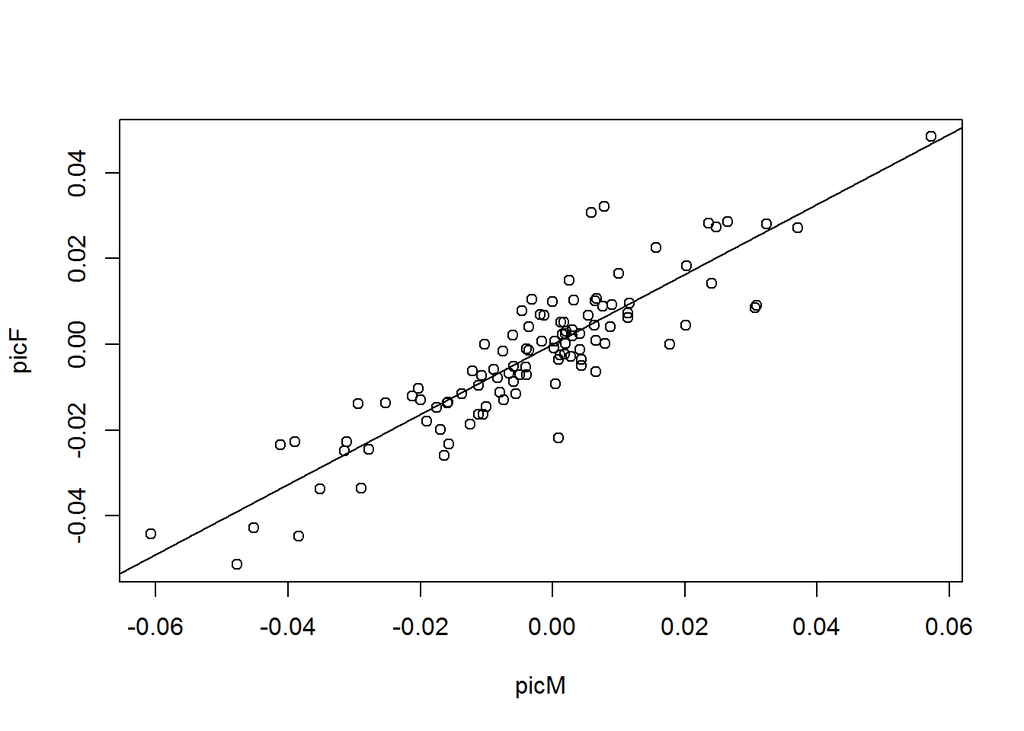

```r
plot(picF~picM)
abline(lm(picF~picM - 1))
```

The approach is also appropriate for anova-models, and for multivariate data (using D-PGLS):

```r
  #Phylogenetic anova
procD.pgls(fml~ecomorph,phy=tree,data=gdf, print.progress = FALSE)
```

```
##
## Call:
## procD.pgls(f1 = fml ~ ecomorph, phy = tree, data = gdf, print.progress = FALSE)
##
##
##
##
## Type I (Sequential) Sums of Squares and Cross-products
## Randomized Residual Permutation Procedure Used
## 1000 Permutations
##
## *** F values, Z scores, and P values updated for either PGLS or nested effects
##
##            Df        SS         MS      Rsq      F      Z Pr(>F)
## ecomorph    2 0.0006344 0.00031721 0.020557 1.0809 0.9846  0.201
## Residuals 103 0.0302266 0.00029346
## Total     105 0.0308610
```

```r
anova(gls(Female_SVL~geo_ecomorph, correlation=corBrownian(phy=tree), data=anolis))  #same
```

```
## Denom. DF: 104
##              numDF  F-value p-value
## (Intercept)      1 1276.748  <.0001
## geo_ecomorph     1    1.093  0.2982
```

```r
  #multivariate phy-anova/regression (even when p>N)
procD.pgls(Y~ecomorph,phy=tree,data=gdf, print.progress = FALSE)  #Here Y is multivariate Y~X|phy.
```

```
##
## Call:
## procD.pgls(f1 = Y ~ ecomorph, phy = tree, data = gdf, print.progress = FALSE)
##
##
##
##
## Type I (Sequential) Sums of Squares and Cross-products
## Randomized Residual Permutation Procedure Used
## 1000 Permutations
##
## *** F values, Z scores, and P values updated for either PGLS or nested effects
##
##            Df       SS         MS      Rsq      F       Z Pr(>F)
## ecomorph    2 0.001007 0.00050326 0.014895 0.7787 0.74044  0.278
## Residuals 103 0.066566 0.00064628
## Total     105 0.067573
```

### **2: Phylogenetic PLS (partial least squares)**

One may also account for phylogeny when performing PLS, the multivariate association between two data matrices.

```
##
## Call:
## phylo.integration(A = Y.gpa$coords, phy = plethspecies$phy, partition.gp = land.gps,
##     print.progress = FALSE)
##
##
##
## r-PLS: 0.933
##
## P-value: 0.023
##
## Based on 1000 random permutations
```

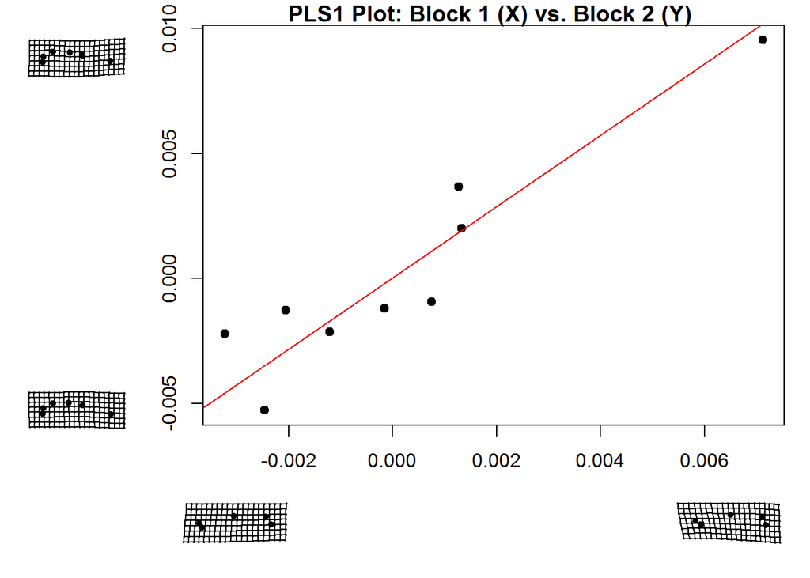

```r
IT<- phylo.integration(Y.gpa$coords,partition.gp=land.gps,phy=plethspecies$phy, print.progress = FALSE)
summary(IT) ; plot(IT)
```

### **3: Phylogenetic Ordination**

A PCA with the phylogeny superimposed is a phylomorphospace. There are numerous functions for accomplishing this (e.g., in phytools): one we will illustrate is in geomorph (note that the ancestral states could be part of the output if anc.states = TRUE:

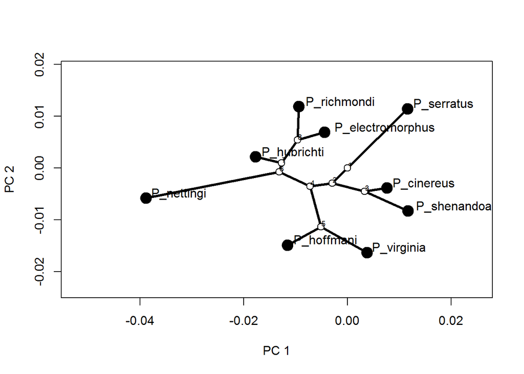

```r
plotGMPhyloMorphoSpace(plethspecies$phy,Y.gpa$coords, ancStates = FALSE)
```

### **4: Phylogenetic Signal**

Phylogenetic signal is the degree to which closely related species display similar trait values. In R this may be implemented in picante, phytools, and geomorph. Multivariate phylogenetic signal is found in geomorph. Here we illustrate this in two packages

```r
phylosig(tree, anolis$Female_SVL, method="K", test=T, nsim=1000)  #phytools
```

```
## [1] "x has no names; assuming x is in the same order as tree$tip.label"
```

```
## $K
## [1] 1.407714
##
## $P
## [1] 0.001
```

```r
physignal(gdf$fml,gdf$tree, print.progress = FALSE)   #geomorph
```

```
##
## Call:
## physignal(A = gdf$fml, phy = gdf$tree, print.progress = FALSE)
##
##
##
## Observed Phylogenetic Signal (K): 1.4077
##
## P-value: 0.001
##
## Based on 1000 random permutations
```

```
##
## Call:
## physignal(A = gdf$Y, phy = gdf$tree, print.progress = FALSE)
##
##
##
## Observed Phylogenetic Signal (K): 1.3058
##
## P-value: 0.001
##
## Based on 1000 random permutations
```

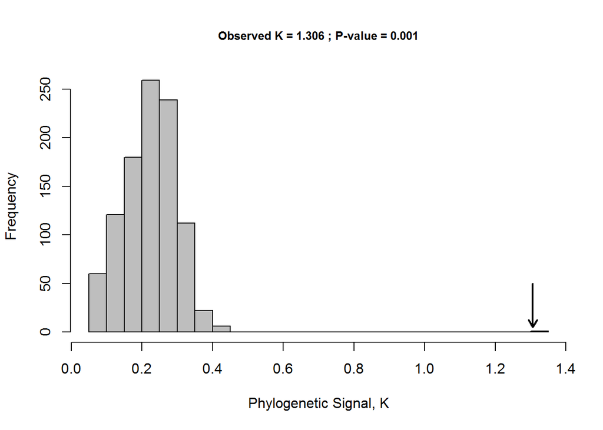

```r
res<-physignal(gdf$Y,gdf$tree, print.progress = FALSE)   #multivariate example
summary(res); plot(res)
```

### **5: Comparing Phylogenetic Evolutionary Rates**

Comparing the rate of phenotypic evolution among groups of taxa is sometimes of interest (e.g., does body size evolve faster in island taxa versus continental species?). The general approach is to fit the data to the phylogeny under a model with a single evolutionary rate for all taxa, and compare this fit to a model with multiple rates for groups of taxa (BM1 vs. BMM). This may be implemented in several packages, one of which is shown here:

```r
  #univariate
compare.evol.rates(A=fml,gp=ecomorph,phy = tree, print.progress = FALSE)
```

```
##
## Call:
##
##
## Observed Rate Ratio: 2.4632
##
## P-value: 0.157
##
## Based on 1000 random permutations
##
## The rate for group 0 is 0.000323196218622704
##
## The rate for group 1 is 0.000150742120096103
##
## The rate for group 2 is 0.000371309192028199
```

```
##
## Call:
##
##
## Observed Rate Ratio: 1.8372
##
## P-value: 0.35
##
## Based on 1000 random permutations
##
## The rate for group 0 is 1.79641754369177e-06
##
## The rate for group 1 is 3.30041235292046e-06
```

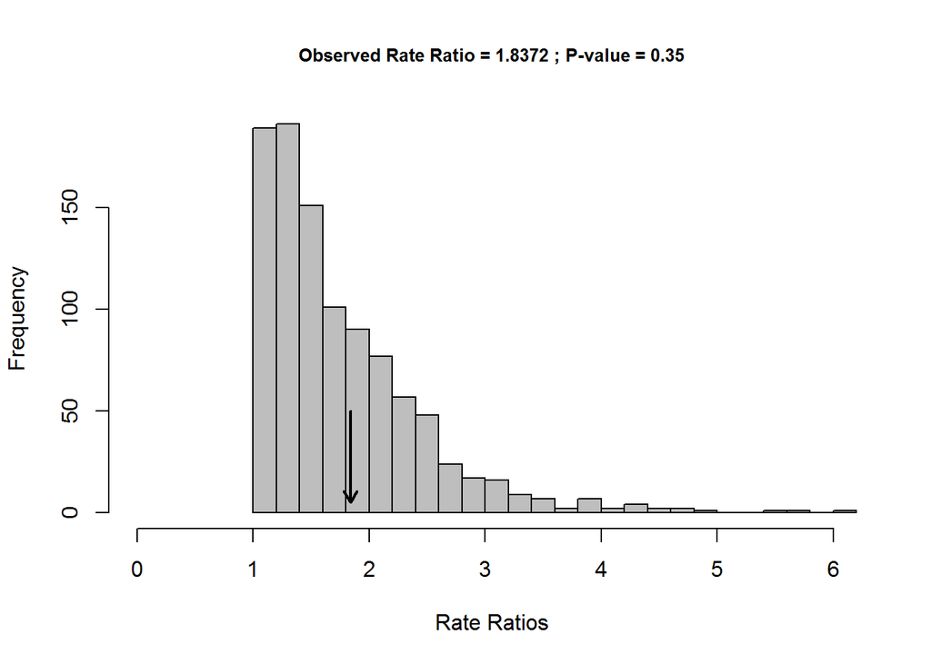

```r
  #multivariate net evolutionary rates
ER<-compare.evol.rates(A=Y.gpa$coords, phy=plethspecies$phy,gp=gp.end, print.progress = FALSE)
summary(ER); plot(ER)
```

### **6: Comparing Evolutionary Models**

The previous section allowed a comparison to BM1 and BMM evolutionary models. However, there is a much broader class of models that could be considered, including Ornstein-Uhlenbeck models, early-burst models, etc. OU models can have one or more optima (OU1, OUM), and more complicated models can be envisioned.

As with Brownian motion rate models, the procedure is straightforward: the fit of the data to the phylogeny under a specified evolutionary model is obtained, along with the corresponding logL and AIC. Next, these are used to compare the fit of models to determine which has the highest support. A simple example is below (NOTE: The package OUCH, MVSLOUCH, OUwie, and others can compare more complicated models: BM1, BMM, OU1, OUM, etc.).

```r
geo=get(data(geospiza))      #a smaller dataset (for time reasons)
tmp=treedata(geo$phy, geo$dat)
```

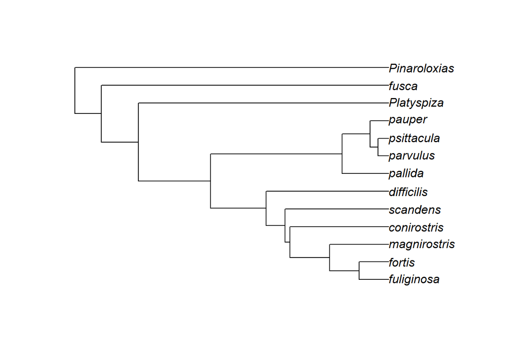

```r
phy=tmp$phy; dat=tmp$data[,"tarsusL"]
plot(phy)
```

```r
bm.M<-fitContinuous(phy, dat, model="BM")
ou.M<-fitContinuous(phy, dat, bounds = list(alpha = c(min = exp(-500), max = exp(2))),model="OU")
  bm.M
```

```
## GEIGER-fitted comparative model of continuous data
##  fitted 'BM' model parameters:
##  sigsq = 0.049339
##  z0 = 3.020419
##
##  model summary:
##  log-likelihood = 10.567317
##  AIC = -17.134634
##  AICc = -15.934634
##  free parameters = 2
##
## Convergence diagnostics:
##  optimization iterations = 100
##  failed iterations = 0
##  frequency of best fit = 1.00
##
##  object summary:
##  'lik' -- likelihood function
##  'bnd' -- bounds for likelihood search
##  'res' -- optimization iteration summary
##  'opt' -- maximum likelihood parameter estimates
```

```r
  ou.M
```

```
## GEIGER-fitted comparative model of continuous data
##  fitted 'OU' model parameters:
##  alpha = 3.488734
##  sigsq = 0.098524
##  z0 = 3.010718
##
##  model summary:
##  log-likelihood = 11.401555
##  AIC = -16.803111
##  AICc = -14.136444
##  free parameters = 3
##
## Convergence diagnostics:
##  optimization iterations = 100
##  failed iterations = 0
##  frequency of best fit = 0.48
##
##  object summary:
##  'lik' -- likelihood function
##  'bnd' -- bounds for likelihood search
##  'res' -- optimization iteration summary
##  'opt' -- maximum likelihood parameter estimates
```

```r
# Compare models: LRT & AIC
LRT.M<-(2*(ou.M$opt$lnL-bm.M$opt$lnL))
prob.M<-pchisq(LRT.M, 1, lower.tail=FALSE)
LRT.M
```

```
## [1] 1.668477
```

```r
prob.M
```

```
## [1] 0.1964627
```

```r
bm.M$opt$aic
```

```
## [1] -17.13463
```

```r
ou.M$opt$aic #OU does not provide a better fit: use simpler model (BM)
```

```
## [1] -16.80311
```